# First Employment Experience

Bart Kudrzycki

3/24/2021

*In this chunk we answer the questions: at what age do urban youth in Benin get their first job? How do job characteristics differ between first jobs and youth who have been working for over a year (more formal? more satisfied?)*

### When do youth leave school? (Graduation age)

The ILO considers the onset of the school-to-work transition to be the school leaving age, as do several studies of the school-to-work transition in OECD countries (Bowers 1998, Quiniti 2014). The weighted mean school leaving age (defined as age in last recorded period of apprenticeship or schooling) for urban youth in Benin is 21.77. The median school-leaving age is 21: in comparison, find median school-leaving ages of 21-22 in advanced economies, 17-18 in Brazil, India, Indonesia, Mexico and Turkey, and 19-20 in Argentina, Chile, and South Africa. We thus expect to also observe school-leaving ages of under 20 given Benin’s level of development. In other words, the school-leaving age of urban youth in Benin is comparable to that of youth in Canada, France, and the United States of America. The distribution of school-leaving ages is approximately normal (shown below).

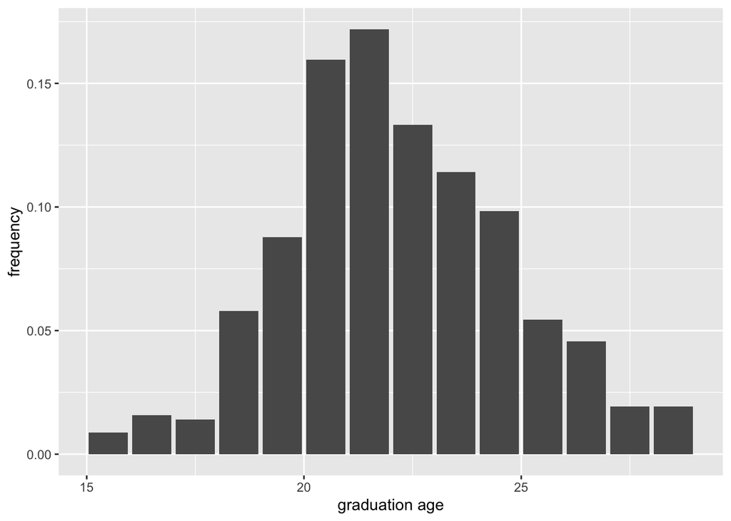

Very few urban youth have never been in education: only 4.44% of youth report having no education, in contrast to 28.8% of youth aged 15-29 who reported having no education in the SWTS. Again, this points to major differences in school attendance in urban and rural areas (can check SWTS!).

### At what age do youth get their first employment experience? Do they enter the labor market as wage employees, self-employed, or NEET?

At the time of the baseline, 269 youth (35.77%) had not had a first employment experience.

Using method 2, we establish that 62.11% of 417 youth who find employment enter the labor market in wage employment. 37.89% of 417 enter the labor market as self-employed.

Using the pooled method, 63.72% of the 339 youth who experience employment start with wage employment. 36.28% of the 339 enter the labor market as self-employed.

There are no significant gender differences in whether youth enter the labor market as wage employed, self-employed, or NEET. Significantly fewer youth enter the labor market as self-employed than wage employed, suggesting the need to accumulate capital before being able to set up an own business.

```r
ys_panel %>%
  filter(wave == 0) %>%
  tbl_summary(by = sex,
            include = c(sex, first_act2),
            missing = "no") %>%
  add_overall() %>%
  add_p()
```

| **Characteristic** | **Overall**, N = 752<sup>1</sup> | **0**, N = 396<sup>1</sup> | **1**, N = 356<sup>1</sup> | **p-value**<sup>2</sup> |
| --- | --- | --- | --- | --- |
| first_act2 |  |  |  | 0.2 |
| Employed | 190 (38%) | 82 (36%) | 108 (40%) |  |
| NEET | 186 (37%) | 94 (41%) | 92 (34%) |  |
| Self-Employed | 125 (25%) | 53 (23%) | 72 (26%) |  |

<sup>*1*</sup> n (%) <sup>*2*</sup> Pearson's Chi-squared test

```r
ys_panel %>%
  filter(wave == 0) %>%
  tbl_summary(by = yeduc,
            include = c(yeduc, first_act2),
            missing = "no") %>%
  add_overall() %>%
  add_p()
```

| **Characteristic** | **Overall**, N = 752<sup>1</sup> | **<Primary**, N = 61<sup>1</sup> | **Collège**, N = 172<sup>1</sup> | **Lycée**, N = 190<sup>1</sup> | **None**, N = 40<sup>1</sup> | **Primary**, N = 76<sup>1</sup> | **Tertiary**, N = 213<sup>1</sup> | **p-value**<sup>2</sup> |
| --- | --- | --- | --- | --- | --- | --- | --- | --- |
| first_act2 |  |  |  |  |  |  |  | 0.10 |
| Employed | 190 (38%) | 7 (24%) | 38 (34%) | 52 (40%) | 3 (23%) | 18 (39%) | 72 (42%) |  |
| NEET | 186 (37%) | 11 (38%) | 44 (40%) | 52 (40%) | 5 (38%) | 10 (22%) | 64 (37%) |  |
| Self-Employed | 125 (25%) | 11 (38%) | 29 (26%) | 26 (20%) | 5 (38%) | 18 (39%) | 36 (21%) |  |

<sup>*1*</sup> n (%) <sup>*2*</sup> Pearson's Chi-squared test

```r
ys_panel %>%
  filter(wave == 0) %>%
  tbl_summary(by = formapp,
            include = c(formapp, first_act2),
            missing = "no") %>%
  add_overall() %>%
  add_p()
```

| **Characteristic** | **Overall**, N = 752<sup>1</sup> | **0**, N = 601<sup>1</sup> | **1**, N = 151<sup>1</sup> | **p-value**<sup>2</sup> |
| --- | --- | --- | --- | --- |
| first_act2 |  |  |  | 0.046 |
| Employed | 190 (38%) | 150 (37%) | 40 (41%) |  |
| NEET | 186 (37%) | 160 (40%) | 26 (27%) |  |
| Self-Employed | 125 (25%) | 94 (23%) | 31 (32%) |  |

<sup>*1*</sup> n (%) <sup>*2*</sup> Pearson's Chi-squared test

```r
ys_panel %>%
  filter(wave == 0) %>%
  tbl_summary(by = meduc,
            include = c(meduc, first_act2),
            missing = "no") %>%
  add_overall() %>%
  add_p()
```

[output not shown]

| **Characteristic** | **Overall**, N = 752<sup>1</sup> | **<Primary**, N = 107<sup>1</sup> | **Collège**, N = 78<sup>1</sup> | **Lycée**, N = 35<sup>1</sup> | **None**, N = 439<sup>1</sup> | **Other**, N = 27<sup>1</sup> | **Primary**, N = 58<sup>1</sup> | **Tertiary**, N = 8<sup>1</sup> | **p-value** |
| --- | --- | --- | --- | --- | --- | --- | --- | --- | --- |
| first_act2 |  |  |  |  |  |  |  |  |  |
| Employed | 190 (38%) | 39 (48%) | 23 (43%) | 12 (50%) | 100 (36%) | 3 (18%) | 10 (26%) | 3 (38%) |  |
| NEET | 186 (37%) | 31 (38%) | 20 (38%) | 8 (33%) | 96 (34%) | 8 (47%) | 19 (49%) | 4 (50%) |  |
| Self-Employed | 125 (25%) | 11 (14%) | 10 (19%) | 4 (17%) | 83 (30%) | 6 (35%) | 10 (26%) | 1 (12%) |  |

<sup>*1*</sup> n (%)

```r
ys_panel %>%
  filter(wave == 0) %>%
  tbl_summary(by = feduc,
            include = c(feduc, first_act2),
            missing = "no") %>%
  add_overall() %>%
  add_p()
```

| **Characteristic** | **Overall**, N = 752<sup>1</sup> | **<Primary**, N = 109<sup>1</sup> | **Collège**, N = 122<sup>1</sup> | **Lycée**, N = 89<sup>1</sup> | **None**, N = 245<sup>1</sup> | **Other**, N = 41<sup>1</sup> | **Primary**, N = 87<sup>1</sup> | **Tertiary**, N = 59<sup>1</sup> | **p-value**<sup>2</sup> |
| --- | --- | --- | --- | --- | --- | --- | --- | --- | --- |
| first_act2 |  |  |  |  |  |  |  |  | 0.033 |
| Employed | 190 (38%) | 25 (34%) | 28 (35%) | 20 (31%) | 60 (39%) | 12 (50%) | 23 (35%) | 22 (54%) |  |
| NEET | 186 (37%) | 31 (42%) | 35 (43%) | 33 (51%) | 46 (30%) | 5 (21%) | 21 (32%) | 15 (37%) |  |
| Self-Employed | 125 (25%) | 17 (23%) | 18 (22%) | 12 (18%) | 46 (30%) | 7 (29%) | 21 (32%) | 4 (9.8%) |  |

<sup>*1*</sup> n (%) <sup>*2*</sup> Pearson's Chi-squared test

### How do the jobs of labor market entrants differ from established labor market participants?

|  | **Overall**, N = 251,311<sup>1</sup> | **0** N=355 (47%)<sup>1</sup> | **1** N=397 (53%)<sup>1</sup> |
| --- | --- | --- | --- |
| YS8_4 |  |  |  |
| I am self-employed | 125 / 306 (41%) | 28 / 60 (45%) | 97 / 246 (40%) |
| I help out in the family business | 6 / 306 (2.1%) | 0 / 60 (0%) | 6 / 246 (2.6%) |
| I work as a paid or unpaid apprentice | 4 / 306 (1.0%) | 3 / 60 (4.4%) | 1 / 246 (0.2%) |
| I work for different employers on an irregular basis | 21 / 306 (6.2%) | 4 / 60 (6.7%) | 17 / 246 (6.1%) |
| I work for ONE employer on a regular basis | 75 / 306 (24%) | 7 / 60 (11%) | 68 / 246 (28%) |
| I work for ONE employer on an irregular basis | 70 / 306 (24%) | 15 / 60 (28%) | 55 / 246 (23%) |
| Other (specify) | 5 / 306 (1.6%) | 3 / 60 (5.1%) | 2 / 246 (0.7%) |
| YS8_5 |  |  |  |
| Accommodation and food service activities | 13 / 177 (8.6%) | 1 / 29 (6.2%) | 12 / 148 (9.0%) |
| Agriculture, fishing, or livestock | 2 / 177 (1.8%) | 0 / 29 (0%) | 2 / 148 (2.1%) |
| Construction (including plumbing, electricity, masonry, and metalwork) | 12 / 177 (8.3%) | 5 / 29 (19%) | 7 / 148 (6.1%) |
| Manufacturing of a good (e.g. furniture) | 6 / 177 (3.5%) | 1 / 29 (6.2%) | 5 / 148 (3.0%) |
| Other (specify) | 66 / 177 (38%) | 13 / 29 (39%) | 53 / 148 (38%) |
| Professional, scientific and technical activities | 32 / 177 (15%) | 4 / 29 (11%) | 28 / 148 (15%) |
| Repair of motor vehicles and motorcycles | 2 / 177 (2.5%) | 0 / 29 (0%) | 2 / 148 (3.0%) |
| Transportation of goods or people | 9 / 177 (5.6%) | 1 / 29 (2.5%) | 8 / 148 (6.2%) |
| Wholesale and retail trade | 35 / 177 (17%) | 4 / 29 (15%) | 31 / 148 (18%) |
| YS8_9 |  |  |  |
| 11-20 | 23 / 177 (12%) | 1 / 29 (2.6%) | 22 / 148 (14%) |
| 2 | 52 / 177 (32%) | 16 / 29 (58%) | 36 / 148 (27%) |
| 21-50 | 15 / 177 (8.7%) | 2 / 29 (5.1%) | 13 / 148 (9.4%) |
| 3 | 13 / 177 (5.9%) | 1 / 29 (1.3%) | 12 / 148 (6.8%) |
| 4 | 17 / 177 (11%) | 4 / 29 (13%) | 13 / 148 (10%) |
| 5 | 16 / 177 (11%) | 1 / 29 (6.2%) | 15 / 148 (11%) |
| 51-500 | 8 / 177 (3.8%) | 3 / 29 (7.8%) | 5 / 148 (2.9%) |
| 6-10 | 29 / 177 (15%) | 1 / 29 (6.2%) | 28 / 148 (17%) |
| more than 500 | 4 / 177 (1.8%) | 0 / 29 (0%) | 4 / 148 (2.2%) |
| YS8_10 |  |  |  |
| No contract | 98 / 177 (62%) | 23 / 29 (82%) | 75 / 148 (58%) |
| Verbal contract | 33 / 177 (16%) | 4 / 29 (14%) | 29 / 148 (16%) |
| Written contract | 46 / 177 (22%) | 2 / 29 (4.0%) | 44 / 148 (26%) |
| YS8_11 |  |  |  |
| Limited | 41 / 79 (54%) | 4 / 6 (78%) | 37 / 73 (52%) |
| Unlimited | 38 / 79 (46%) | 2 / 6 (22%) | 36 / 73 (48%) |
| YS8_12 |  |  |  |
| 1-2 weeks | 8 / 79 (10%) | 0 / 6 (0%) | 8 / 73 (11%) |
| 2 | 1 / 79 (1.4%) | 0 / 6 (0%) | 1 / 73 (1.5%) |
| 3-4 weeks | 14 / 79 (18%) | 0 / 6 (0%) | 14 / 73 (20%) |
| 6 | 1 / 79 (0.6%) | 1 / 6 (7.2%) | 0 / 73 (0%) |
| more than 4 weeks | 16 / 79 (22%) | 1 / 6 (15%) | 15 / 73 (22%) |
| None | 39 / 79 (48%) | 4 / 6 (78%) | 35 / 73 (45%) |
| YS8_15 | 8.6 | 5.5 | 9.2 |
| days_worked | 5.07 | 5.08 | 5.06 |
| YS8_19 | 9.9 | 9.8 | 10.0 |
| YS8_24 |  |  |  |
| 0 FCFA | 3 / 114 (3.2%) | 0 / 6 (0%) | 3 / 108 (3.4%) |
| 10.000-19.999 FCFA | 1 / 114 (0.8%) | 0 / 6 (0%) | 1 / 108 (0.9%) |
| 110.000-149.999 FCFA | 2 / 114 (1.4%) | 0 / 6 (0%) | 2 / 108 (1.5%) |
| 150.000-199.999 FCFA | 4 / 114 (3.0%) | 0 / 6 (0%) | 4 / 108 (3.1%) |
| 20.000-34.999 FCFA | 29 / 114 (28%) | 3 / 6 (63%) | 26 / 108 (26%) |
| 35.000-54.999 FCFA | 44 / 114 (35%) | 2 / 6 (22%) | 42 / 108 (36%) |
| 55.000-79.999 FCFA | 17 / 114 (14%) | 1 / 6 (15%) | 16 / 108 (14%) |
| 80.000-109.999 FCFA | 14 / 114 (14%) | 0 / 6 (0%) | 14 / 108 (14%) |
| YS8_26 |  |  |  |
| 1 | 9 / 177 (4.9%) | 2 / 29 (9.0%) | 7 / 148 (4.1%) |
| 2 | 98 / 177 (58%) | 18 / 29 (61%) | 80 / 148 (57%) |
| 3 | 44 / 177 (24%) | 5 / 29 (20%) | 39 / 148 (24%) |
| 4 | 26 / 177 (14%) | 4 / 29 (9.7%) | 22 / 148 (15%) |
| YS8_28 |  |  |  |
| 1 | 49 / 177 (26%) | 8 / 29 (26%) | 41 / 148 (26%) |
| 2 | 128 / 177 (74%) | 21 / 29 (74%) | 107 / 148 (74%) |
| YS8_29 |  |  |  |
| 1 | 167 / 177 (94%) | 29 / 29 (100%) | 138 / 148 (93%) |
| 2 | 10 / 177 (5.5%) | 0 / 29 (0%) | 10 / 148 (6.7%) |
| How satisfied are you with your current job, on a scale of 1 (very dissatisfied) |  |  |  |
| 1. Very dissatisfied | 4 / 177 (1.8%) | 0 / 29 (0%) | 4 / 148 (2.2%) |
| 2. Dissatisfied | 31 / 177 (19%) | 7 / 29 (21%) | 24 / 148 (18%) |
| 3. Neither satisfied nor dissatisfied | 36 / 177 (19%) | 5 / 29 (15%) | 31 / 148 (20%) |
| 4. Satisfied | 92 / 177 (48%) | 14 / 29 (54%) | 78 / 148 (47%) |
| 5. Very Satisfied | 14 / 177 (12%) | 3 / 29 (10%) | 11 / 148 (13%) |
| YS8_35 |  |  |  |
| 1 | 63 / 177 (31%) | 9 / 29 (25%) | 54 / 148 (32%) |
| 2 | 114 / 177 (69%) | 20 / 29 (75%) | 94 / 148 (68%) |

<sup>*1*</sup> n_unweighted / N_unweighted (%); Mean

### What paths do youth take to their first jobs?

483, or 64.23%, of youth report having ever been employed at some point in the past seven years; 230, or 30.59 %, of youth report being self-employed at some point in the past seven years; and 327, or 43.48%, of youth report having wage employment at some point in the past seven years.

### What are the determinants of first labor market experience?

**FAZIT: First jobs are more likely to be informal, as in Cunningham. Too few observations for first labor market wage jobs to draw conclusions**